# IE6400 Foundations for Data Analytics Engineering

# Fall 2023

### Module 2: Statistical Experiments and Significance Testing

#### Statistical Experiments:

- Statistical experiments are systematic methods for collecting data and drawing conclusions about populations. They include selecting a sample, applying a treatment, and measuring outcomes. Planning, involving randomization and control groups, ensures reliable data. These experiments are essential for testing hypotheses and gaining insights from sample data in scientific research.

#### Significance Testing:

- Significance testing assesses if observed data differences are significant or due to chance. It involves forming null and alternative hypotheses, collecting sample data, calculating a test statistic, and comparing the p-value to a significance level. Researchers use this method to determine if findings are statistically significant, helping make informed decisions from empirical data.

The functions you've imported from `math` and `statistics` are part of Python's standard library, so you don't need to install any additional libraries to use them. These libraries are included with Python by default, so you can use them in your code without any further installation.

You can now use these functions for mathematical and statistical calculations in your Python script.

```python
#importing necessary libraries for statistical operations.
import itertools
from math import sqrt
from statistics import mean, variance, stdev, pvariance, pstdev
```

This command will install the following libraries:

**numpy:** NumPy is a fundamental package for scientific computing with Python. It provides support for arrays, matrices, and a collection of mathematical functions to operate on these arrays.

**matplotlib:** Matplotlib is a popular library for creating static, animated, and interactive visualizations in Python.

**scipy:** SciPy is an open-source library for mathematics, science, and engineering. It builds on NumPy and provides additional functionality for optimization, integration, interpolation, eigenvalue problems, and more.

```python
!pip install numpy matplotlib scipy
```

#### Excercise 1 Find the population variance and standard deviation

# Problem Statement

Corporation A has recently hired 10 new employees, and the starting salaries (in thousands of dollars) for these employees are listed as follows: [41, 38, 39, 45, 47, 41, 44, 41, 37, 42]

Determine the following for the starting salaries of these employees:

1. The population variance.
2. The population standard deviation.

```python
# Importing necessary libraries that provide a comprehensive ecosystem
# for scientific computing and data analysis in Python.
import matplotlib.pyplot as plt
from scipy.stats import t, norm
```

Creating the dataset:

```python
# Data: Starting salaries for Corporation A
salaries = [41, 38, 39, 45, 47, 41, 44, 41, 37, 42]

# Calculate the number of data points
N = len(salaries)

print(salaries)
print(N)
```

```
[41, 38, 39, 45, 47, 41, 44, 41, 37, 42]
10
```

```python
# Calculate the mean (average) salary
mean_val = sum(salaries) / N

# Calculate population variance from scratch
# - It measures how data points are dispersed around the mean.
# - It sums the squared differences between each salary and the mean, then divides by the number of data points.
p_variance = sum([(salary - mean_val) ** 2 for salary in salaries]) / N

# Calculate the population standard deviation from the calculated variance
# - Standard deviation is the square root of the variance.
std = sqrt(p_variance)
```

Printing the Calculated Values :

```python
# Print results calculated from scratch
print('# Formulas from scratch')
print('population variance =', round(p_variance, 3))
print('population standard deviation =', round(std, 3), end='\n\n')

# Calculate population variance and standard deviation using statistics module
# - The statistics module provides built-in functions for these calculations.
p_variance = pvariance(salaries)  # Calculate population variance using pvariance()
std = pstdev(salaries)  # Calculate population standard deviation using pstdev()

# Print results using statistics module
print('# Using pvariance, pstdev')
print('population variance with statistics =', round(p_variance, 3))
print('population standard deviation with statistics =', round(std, 3))
```

```
# Formulas from scratch
population variance = 8.85
population standard deviation = 2.975

# Using pvariance, pstdev
population variance with statistics = 8.85
population standard deviation with statistics = 2.975
```

#### 1. Calculate the mean (average) of the salaries:

$\mu = \frac{\sum x}{N}$ Where $\sum x$ is the sum of all salaries and ( N ) is the number of salaries.

$\mu = \frac{41 + 38 + 39 + 45 + 47 + 41 + 44 + 41 + 37 + 42}{10}$

$\mu = \frac{415}{10}$

$\mu = 41.5$

#### 2. Calculate the population variance ($\sigma^2$):

$\sigma^2 = \frac{\sum (x - \mu)^2}{N}$

Using the salaries and the mean (41.5) we calculated:

$\sigma^2 = \frac{(41-41.5)^2 + (38-41.5)^2 + (39-41.5)^2 + ... + (42-41.5)^2}{10}$

$\sigma^2 = \frac{0.25 + 12.25 + 6.25 + 12.25 + 30.25 + 0.25 + 6.25 + 0.25 + 20.25 + 0.25}{10}$

#### 3. Calculate the population standard deviation ($\sigma$):

$\sigma = \sqrt{\sigma^2}$

$\sigma \approx 2.97$

#### Exercise 2 Find the sample variance and standard deviation

In a study of high school football players that suffered concussions, researchers placed the players in two groups. Players that recovered from their concussions in 14 days or less were placed in Group 1. Those that took more than 14 days were placed in Group 2. The recovery times (in days) for Group 1 are listed below. Find the sample variance and standard deviation of the recovery times.

You can calculate the sample variance and standard deviation in Python using the built-in functions in the statistics module or by using NumPy for more complex calculations.

Using the statistics module:

```python
import statistics

data = [4, 7, 6, 7, 9, 5, 8, 10, 9, 8, 7, 10]

mean = statistics.mean(data)  # Calculate the mean
variance = statistics.variance(data)  # Calculate the sample variance
std_deviation = statistics.stdev(data)  # Calculate the sample standard deviation

print("Mean:", mean)
print("Sample Variance:", variance)
print("Sample Standard Deviation:", std_deviation)
```

```
Mean: 7.5
Sample Variance: 3.5454545454545454
Sample Standard Deviation: 1.8829377433825436
```

Using NumPy:

```python
import numpy as np

data = np.array([4, 7, 6, 7, 9, 5, 8, 10, 9, 8, 7, 10])

mean = np.mean(data)  # Calculate the mean
variance = np.var(data, ddof=1)  # Calculate the sample variance with ddof=1 for sample variance
std_deviation = np.std(data, ddof=1)  # Calculate the sample standard deviation with ddof=1

print("Mean:", mean)
print("Sample Variance:", variance)
print("Sample Standard Deviation:", std_deviation)
```

```
Mean: 7.5
Sample Variance: 3.5454545454545454
Sample Standard Deviation: 1.8829377433825436
```

In both cases, you'll get the mean, sample variance, and sample standard deviation of the provided data. Make sure to set the ddof parameter to 1 when using NumPy to calculate the sample variance and standard deviation because it adjusts for the degrees of freedom in a sample.

#### Results and Conclustion:

- Based on the calculated sample variance of 3.545 and sample standard deviation of 1.883, there is some variability in the recovery times of high school football players from concussions within 14 days in Group 1. This data is crucial for researchers as it enables them to determine the range of recovery times, identify any unusual results, evaluate the effectiveness of treatments, and make informed decisions regarding managing concussions.

#### Exercise 3 Calculate Sample Means and Statistics

The number of times four people go grocery shopping in a month is given by the population values {1, 3, 5, 7}. You randomly choose two of the four people, with replacement.

List all possible samples of size $n$ = 2 and calculate the mean of each. These means form the sampling distribution of the sample means.

To find all possible samples of size 𝑛 = 2 from the population {1, 3, 5, 7}, calculate the mean of each sample, and then find the mean, variance, and standard deviation of the sample means, you can use Python. Here's how you can do it:

```python
import itertools
import numpy as np

# Population values
population = [1, 3, 5, 7]

# Calculate all possible samples of size 2 with replacement
samples = list(itertools.product(population, repeat=2))

# Calculate the mean of each sample
sample_means = [np.mean(sample) for sample in samples]

# Calculate the mean, variance, and standard deviation of the sample means
mean_of_sample_means = np.mean(sample_means)
variance_of_sample_means = np.var(sample_means, ddof=1)  # Using ddof=1 for sample variance
std_deviation_of_sample_means = np.std(sample_means, ddof=1)  # Using ddof=1 for sample standard deviation

# Population statistics
population_mean = np.mean(population)
population_variance = np.var(population, ddof=1)
population_std_deviation = np.std(population, ddof=1)

# Print results
print("Sample Means:", sample_means)
print("Mean of Sample Means:", mean_of_sample_means)
print("Variance of Sample Means:", variance_of_sample_means)
print("Standard Deviation of Sample Means:", std_deviation_of_sample_means)

print("Population Mean:", population_mean)
print("Population Variance:", population_variance)
print("Population Standard Deviation:", population_std_deviation)
```

```
Sample Means: [1.0, 2.0, 3.0, 4.0, 2.0, 3.0, 4.0, 5.0, 3.0, 4.0, 5.0, 6.0, 4.0, 5.0, 6.0, 7.0]
Mean of Sample Means: 4.0
Variance of Sample Means: 2.6666666666666665
Standard Deviation of Sample Means: 1.632993161855452
Population Mean: 4.0
Population Variance: 6.666666666666667
Population Standard Deviation: 2.581988897471611
```

#### Exercise 4 Finding a Point Estimate

A researcher is collecting data about a college athletic conference and its student-athletes. A random sample of 40 student-athletes is selected and their numbers of hours spent on required athletic activities for one week are recorded. Find a point estimate for the population mean $\mu$, the mean number of hours spent on required athletic activities by all student-athletes in the conference.

```python
import numpy as np

# Sample data (hours spent on required athletic activities for 40 student-athletes)
sample_data = [15, 18, 20, 22, 17, 19, 21, 16, 23, 18,
               20, 19, 17, 18, 22, 21, 19, 20, 16, 25,
               24, 22, 20, 18, 17, 19, 20, 21, 18, 17,
               19, 18, 20, 22, 21, 19, 20, 18, 17, 16]

# Calculate the point estimate for the population mean
point_estimate = np.mean(sample_data)

# Print the point estimate
print("Point Estimate for Population Mean (𝜇):", point_estimate)
```

```
Point Estimate for Population Mean (𝜇): 19.3
```

#### Exercise 5 Calculating and Visualizing a 95% Confidence Interval for a Population Mean ($\mu$)

- An **interval estimate** is an interval, or range of values, used to estimate a population parameter.
- The **level of confidence** $c$ is the probability that the interval estimate contains the population parameter, assuming that the estimation process is repeated a large number of times.

The level of confidence $c$ is the area under the standard normal curve between the `critical values`, $-z_c$ and $z_c$.

**Critical values** are values that separate sample statistics that are probable from sample statistics that are improbable, or unusual.

Below is an example of calculating a 95% confidence interval for a population mean and plotting the confidence interval on a normal distribution curve using Python. In this example, I'm using a sample mean of 21.1, a known population standard deviation of 2, and a sample size of 30.

```python
import math
import matplotlib.pyplot as plt
import numpy as np
from scipy.stats import norm

# Given values
sample_mean = 21.1
population_std_dev = 2
sample_size = 30
confidence_level = 0.95

# Z-score for 95% confidence
z_score = norm.ppf((1 + confidence_level) / 2)

# Calculate margin of error
margin_error = z_score * (population_std_dev / math.sqrt(sample_size))

# Calculate confidence interval
lower_limit = sample_mean - margin_error
upper_limit = sample_mean + margin_error

# Output the confidence interval
print(f"The 95% confidence interval for the population mean is ({lower_limit:.2f}, {upper_limit:.2f})")
```

```
The 95% confidence interval for the population mean is (20.38, 21.82)
```

#### Plotting the Curve:

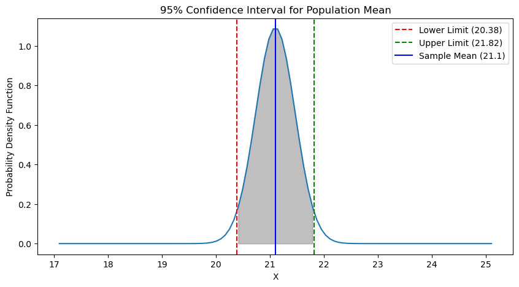

```python
# Plotting the normal distribution
x = np.linspace(sample_mean - 4, sample_mean + 4, 100)
y = norm.pdf(x, sample_mean, population_std_dev / math.sqrt(sample_size))

plt.figure(figsize=(10, 5))
plt.plot(x, y)
plt.axvline(x=lower_limit, color='red', linestyle='--', label=f'Lower Limit ({lower_limit:.2f})')
plt.axvline(x=upper_limit, color='green', linestyle='--', label=f'Upper Limit ({upper_limit:.2f})')
plt.axvline(x=sample_mean, color='blue', label=f'Sample Mean ({sample_mean})')
plt.fill_between(x, y, 0, where=((x > lower_limit) & (x <= upper_limit)), color='gray', alpha=0.5)
plt.legend()
plt.title('95% Confidence Interval for Population Mean')
plt.xlabel('X')
plt.ylabel('Probability Density Function')
plt.show()
```

The output of the Python script will give you a confidence interval for the population mean, and a visual representation of this interval on a normal distribution curve.

### Interpretation:

1. **Confidence Interval (CI)**:
   - Suppose the output gives a confidence interval of ((20.38, 21.82)).
   - This means that we are 95% confident that the true population mean lies between 20.38 and 21.82.
2. **Visualization**:
   - In the plotted normal distribution curve:
     - The sample mean (21.1) is marked with a blue vertical line.
     - The lower and upper limits of the confidence interval are marked with red and green dashed lines, respectively.
     - The area between these two limits is shaded. This shaded area under the curve represents the range of values where we expect the population mean to fall 95% of the time.
3. **Practical Implication**:
   - If we were to take many samples and compute a 95% confidence interval from each of them, we expect about 95% of those intervals to contain the true population mean.
   - It does not mean that there is a 95% probability that any specific interval contains the population mean. The true population mean is either in the interval calculated from a sample, or it is not.
4. **Limitations**:
   - The accuracy of the confidence interval depends on the sample size and the distribution of the population. A larger sample size generally leads to a narrower confidence interval, providing a more precise estimate of the population mean.
   - The method used assumes that the population is normally distributed, or the sample size is large enough to apply the Central Limit Theorem, and that the population standard deviation is known.

In summary, the confidence interval provides a range of values for the population mean, and the visualization helps in understanding the spread and the reliability of this estimate.

#### Two-Sample Z-Test for Mean Credit Card Debts in California and Illinois

We will perform a two-sample z-test to test the claim that there is a difference in the mean credit card debts of households in California and Illinois.

##### Given:

- $\sigma_{1}$ = \$960 (Standard deviation for California)
- $\sigma_{2}$ = \$845 (Standard deviation for Illinois)
- $\alpha$ = 0.05 (Significance level)

#### Assumptions:

We assume the sample means (( $\bar{x_1}$ ) and ( $\bar{x_2}$ )) and sample sizes (( $n_1$ ) and ( $n_2$ )) are given.

```python
import numpy as np
import matplotlib.pyplot as plt
import scipy.stats as stats

# Given values
x_bar1 = 3060  # Sample mean for California
x_bar2 = 2910  # Sample mean for Illinois
sigma1 = 960  # Standard deviation for California
sigma2 = 845  # Standard deviation for Illinois
n1 = 250  # Sample size for California
n2 = 250  # Sample size for Illinois

# Calculate the z-value
z_value = (x_bar1 - x_bar2) / np.sqrt((sigma1**2/n1) + (sigma2**2/n2))

# Calculate the critical z-values for alpha = 0.05 (two-tailed)
alpha = 0.05
z_critical_left = stats.norm.ppf(alpha/2)  # Left critical value
z_critical_right = stats.norm.ppf(1 - alpha/2)  # Right critical value

# Decision-making
if z_value < z_critical_left or z_value > z_critical_right:
    decision = "Reject the null hypothesis. There is a significant difference in the mean credit card debts between California and Illinois."
else:
    decision = "Fail to reject the null hypothesis. There isn't enough evidence to support a significant difference in the mean credit card debts between California and Illinois."

print(decision)
```

```
Fail to reject the null hypothesis. There isn't enough evidence to support a significant difference in the mean credit card debts between California and Illinois.
```

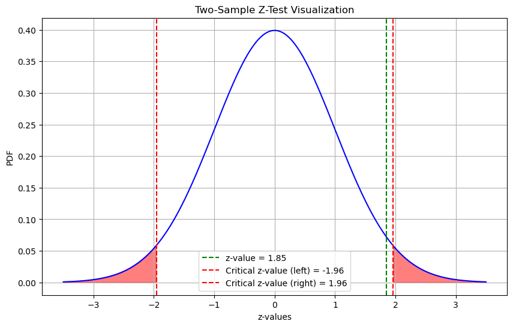

```python
# Visualization
x = np.linspace(-3.5, 3.5, 1000)
y = stats.norm.pdf(x, 0, 1)  # Standard normal distribution

plt.figure(figsize=(10, 6))
plt.plot(x, y, color='blue')

# Shade the regions beyond the critical z-values
plt.fill_between(x, y, where=(x < z_critical_left), color='red', alpha=0.5)
plt.fill_between(x, y, where=(x > z_critical_right), color='red', alpha=0.5)

# Plot the computed z-value
plt.axvline(z_value, color='green', linestyle='--', label=f'z-value = {z_value:.2f}')
plt.axvline(z_critical_left, color='red', linestyle='--', label=f'Critical z-value (left) = {z_critical_left:.2f}')
plt.axvline(z_critical_right, color='red', linestyle='--', label=f'Critical z-value (right) = {z_critical_right:.2f}')

plt.title("Two-Sample Z-Test Visualization")
plt.xlabel("z-values")
plt.ylabel("PDF")
plt.legend()
plt.grid(True)
plt.show()
```

We conclude that we failed to reject the null hypothesis. There isn't enough evidence to support a significant difference in the mean credit card debts between California and Illinois.

#### Exercise 7 Two-Sample Z-Test for Analyzing Mean Annual Wages of Forensic Science Technicians in Local and State Governments

A survey indicates that the mean annual wages for forensic science technicians working for local and state governments are 60680 and 59430, respectively. The survey includes a randomly selected sample of size 100 from each government branch. Assume that the population standard deviations are 6200 (local) and 5575 (state). The two samples are independent. At $\alpha$ = 0.10, is there enough evidence to conclude that there is a difference in the mean annual wages?

#### Two-Sample Z-Test for Comparing Mean Annual Wages for Forensic Science Technicians

We will perform a two-sample z-test to test whether there is a significant difference in the mean annual wages for forensic science technicians working for local and state governments.

#### Given:

- ( $\bar{x_1}$ = \$60680 ) (Sample mean for local government)
- ( $\bar{x_2}$ = \$59430 ) (Sample mean for state government)
- ( $\sigma_1$ = \$6200 ) (Standard deviation for local government)
- ( $\sigma_2$ = \$5575 ) (Standard deviation for state government)
- ( $n_1 = n_2$ = 100 ) (Sample size for both local and state government)
- ( $\alpha$ = 0.10 ) (Significance level)

```python
import math
from scipy.stats import norm

# Given values
x_bar1 = 60680  # Sample mean for local government
x_bar2 = 59430  # Sample mean for state government
sigma1 = 6200  # Standard deviation for local government
sigma2 = 5575  # Standard deviation for state government
n1 = n2 = 100  # Sample size for both local and state government
alpha = 0.10  # Significance level

# Calculate the z-statistic
z = (x_bar1 - x_bar2) / math.sqrt((sigma1 ** 2 / n1) + (sigma2 ** 2 / n2))

# Calculate the critical value from the z-table
z_critical = norm.ppf(1 - alpha / 2)

# Decision
if abs(z) > z_critical:
    result = {
        "decision": "Reject the null hypothesis",
        "z": z,
        "z_critical": z_critical,
        "interpretation": "There is enough evidence to conclude that there is a difference in the mean annual wages."
    }
else:
    result = {
        "decision": "Do not reject the null hypothesis",
        "z": z,
        "z_critical": z_critical,
        "interpretation": "There is not enough evidence to conclude that there is a difference in the mean annual wages."
    }

result
```

```
{'decision': 'Do not reject the null hypothesis',
 'z': 1.4991779262993403,
 'z_critical': 1.6448536269514722,
 'interpretation': 'There is not enough evidence to conclude that there is a difference in the mean annual wages.'}
```

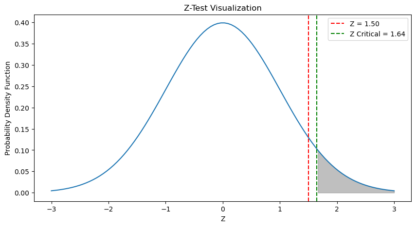

```python
# Visualization
x = np.linspace(-3, 3, 100)
y = norm.pdf(x, 0, 1)
plt.figure(figsize=(10, 5))
plt.plot(x, y)
plt.axvline(x=z, color='red', linestyle='--', label=f'Z = {z:.2f}')
plt.axvline(x=z_critical, color='green', linestyle='--', label=f'Z Critical = {z_critical:.2f}')
plt.fill_between(x, y, 0, where=(x > z_critical), color='gray', alpha=0.5)
plt.legend()
plt.title('Z-Test Visualization')
plt.xlabel('Z')
plt.ylabel('Probability Density Function')
plt.show()
```

- Because $z-score$ is not in the rejection region, you fail to reject the null hypothesis ($H_{0}$).
- There is not enough evidence at the 10% level of significance to support the claim that there is a difference in the mean annual wages for forensic science technicians working for local and state governments.

#### One-Tailed Two-Sample Z-Test for Average Daily Cost of Vacationing in Texas and Virginia

We will perform a one-tailed two-sample z-test to test the claim that the average daily cost of vacationing in Texas is less than the average daily cost in Virginia.

#### Given:

- ( $\sigma_1$ = 20 ) (Standard deviation for Texas)
- ( $\sigma_2$ = 25 ) (Standard deviation for Virginia)
- ( $\alpha$ = 0.01 ) (Significance level)

#### Assumptions:

- ( $\bar{x_1}$ = 100 ) (Sample mean for Texas, assumed)
- ( $\bar{x_2}$ = 120 ) (Sample mean for Virginia, assumed)
- ( $n_1 = n_2$ = 30 ) (Sample size for both Texas and Virginia, assumed)

**Claim:** "The average daily cost of meals and lodging for vacationing in Texas is less than the average daily cost in Virginia"

$H_{0}$: $\mu_{1} \ge \mu_{2}$ and $H_{a}$: $\mu_{1} < \mu_{2}$. (Claim)

```
{'decision': 'Reject the null hypothesis', 'z': -3.4215956910732066, 'z_critical': -2.3263478740408408, 'interpretation': 'There is enough evidence to support the claim that the average daily cost in Texas is less than in Virginia.'}
```

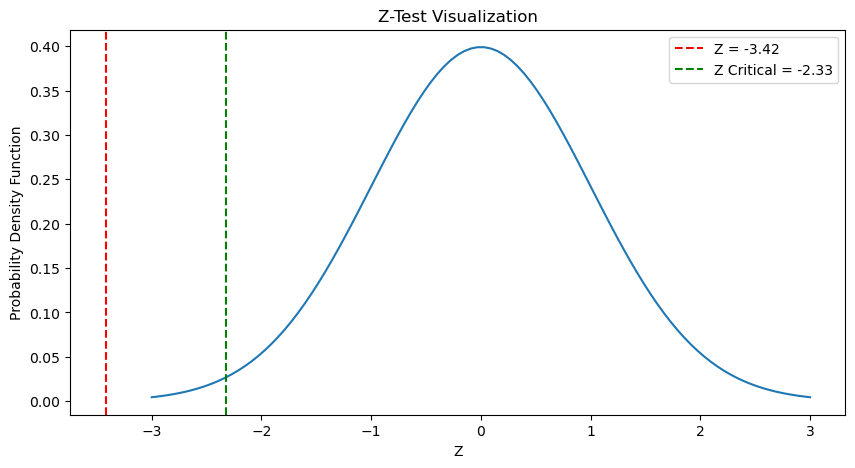

```python
import math
import matplotlib.pyplot as plt
import numpy as np
from scipy.stats import norm

# Given values
sigma1 = 20  # Standard deviation for Texas
sigma2 = 25  # Standard deviation for Virginia
alpha = 0.01  # Significance level

# Assumed sample means and sample sizes
x_bar1 = 100  # Sample mean for Texas
x_bar2 = 120  # Sample mean for Virginia
n1 = n2 = 30  # Sample size for both Texas and Virginia

# Calculate the z-statistic
z = (x_bar1 - x_bar2) / math.sqrt((sigma1 ** 2 / n1) + (sigma2 ** 2 / n2))

# Calculate the critical value from the z-table
z_critical = norm.ppf(alpha)

# Decision
if z < z_critical:
    result = {
        "decision": "Reject the null hypothesis",
        "z": z,
        "z_critical": z_critical,
        "interpretation": "There is enough evidence to support the claim that the average daily cost in Texas is less than in Virginia."
    }
else:
    result = {
        "decision": "Do not reject the null hypothesis",
        "z": z,
        "z_critical": z_critical,
        "interpretation": "There is not enough evidence to support the claim that the average daily cost in Texas is less than in Virginia."
    }

# Output the result
print(result)

# Visualization
x = np.linspace(-3, 3, 100)
y = norm.pdf(x, 0, 1)
plt.figure(figsize=(10, 5))
plt.plot(x, y)
plt.axvline(x=z, color='red', linestyle='--', label=f'Z = {z:.2f}')
plt.axvline(x=z_critical, color='green', linestyle='--', label=f'Z Critical = {z_critical:.2f}')
plt.fill_between(x, y, 0, where=(x < z), color='gray', alpha=0.5)
plt.legend()
plt.title('Z-Test Visualization')
plt.xlabel('Z')
plt.ylabel('Probability Density Function')
plt.show()
```

#### Output Interpretation:

The output provides the following information:

**Decision**: "Reject the null hypothesis"

- This is the conclusion of the hypothesis test. The calculated z-value is beyond the critical z-value in the left tail of the normal distribution, leading to the rejection of the null hypothesis.

**Z**: -3.4215956910732066

- This is the calculated z-statistic, which measures how many standard deviations the sample mean is from the population mean. A negative z-value indicates that the sample mean is below the population mean.

**Z Critical**: -2.3263478740408408

- This is the critical z-value for a one-tailed test at ( $\alpha = 0.01$ ). If the calculated z-value is less than this critical value, we reject the null hypothesis.

**Interpretation**: "There is enough evidence to support the claim that the average daily cost in Texas is less than in Virginia."

#### One-Tailed Two-Sample Z-Test for Average Daily Cost of Vacationing in Alaska and Colorado

We will perform a one-tailed two-sample z-test to test the claim that the average daily cost of vacationing in Alaska is greater than the average daily cost in Colorado.

#### Given:

- ( $\sigma_1$ = 25 ) (Standard deviation for Alaska)
- ( $\sigma_2$ = 20 ) (Standard deviation for Colorado)
- ( $\alpha$ = 0.05 ) (Significance level)

#### Assumptions:

- ( $\bar{x_1}$ = 150 ) (Sample mean for Alaska, assumed)
- ( $\bar{x_2}$ = 130 ) (Sample mean for Colorado, assumed)
- ( $n_1 = n_2$ = 40 ) (Sample size for both Alaska and Colorado, assumed)

**Claim:** "The average daily cost of meals and lodging for vacationing in Alaska is greater than the average daily cost in Colorado."

$H_{0}$: $\mu_{1} \le \mu_{2}$ and $H_{a}$: $\mu_{1} > \mu_{2}$. (Claim)

```python
# Importing necessary libraries
import math
import matplotlib.pyplot as plt
import numpy as np
from scipy.stats import norm

# Given values
sigma1 = 25  # Standard deviation for Alaska
sigma2 = 20  # Standard deviation for Colorado
alpha = 0.05  # Significance level

# Assumed sample means and sample sizes
x_bar1 = 150  # Sample mean for Alaska
x_bar2 = 130  # Sample mean for Colorado
n1 = n2 = 40  # Sample size for both Alaska and Colorado

# Calculate the z-statistic
z = (x_bar1 - x_bar2) / math.sqrt((sigma1 ** 2 / n1) + (sigma2 ** 2 / n2))

# Calculate the critical value from the z-table
z_critical = norm.ppf(1 - alpha)

# Decision
if z > z_critical:
    result = {
        "decision": "Reject the null hypothesis",
        "z": z,
        "z_critical": z_critical,
        "interpretation": "There is enough evidence to support the claim that the average daily cost in Alaska is greater than in Colorado."
    }
else:
    result = {
        "decision": "Do not reject the null hypothesis",
        "z": z,
        "z_critical": z_critical,
        "interpretation": "There is not enough evidence to support the claim that the average daily cost in Alaska is greater than in Colorado."
    }

# Output the result
print(result)
```

```
{'decision': 'Reject the null hypothesis', 'z': 3.9509183865983584, 'z_critical': 1.6448536269514722, 'interpretation': 'There is enough evidence to support the claim that the average daily cost in Alaska is greater than in Colorado.'}
```

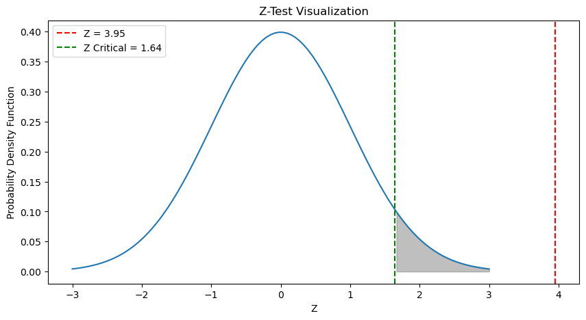

```python
# Visualization
x = np.linspace(-3, 3, 100)
y = norm.pdf(x, 0, 1)
plt.figure(figsize=(10, 5))
plt.plot(x, y)
plt.axvline(x=z, color='red', linestyle='--', label=f'Z = {z:.2f}')
plt.axvline(x=z_critical, color='green', linestyle='--', label=f'Z Critical = {z_critical:.2f}')
plt.fill_between(x, y, 0, where=(x > z_critical), color='gray', alpha=0.5)
plt.legend()
plt.title('Z-Test Visualization')
plt.xlabel('Z')
plt.ylabel('Probability Density Function')
plt.show()
```

#### Output Interpretation:

The output provides the following information:

**Decision**: "Reject the null hypothesis"

- This is the conclusion of the hypothesis test. The calculated z-value is beyond the critical z-value in the right tail of the normal distribution, leading to the rejection of the null hypothesis.

**Z**: 3.9509183865983584

- This is the calculated z-statistic, which measures how many standard deviations the sample mean is from the population mean. A positive z-value indicates that the sample mean is above the population mean.

**Z-Critical**: 1.6448536269514722

- This is the critical z-value for a one-tailed test at ( $\alpha = 0.05$ ). If the calculated z-value is greater than this critical value, we reject the null hypothesis.

**Interpretation**: "There is enough evidence to support the claim that the average daily cost in Alaska is greater than in Colorado."

### Testing the Difference Between Means (Independent Samples, $\sigma_1$ and $\sigma_2$ Unknown)

#### Two-Sample T-Test for Comparing Mean Mathematics Test Scores of Two Teachers

We will perform a two-sample t-test to test whether there is a significant difference in the mean mathematics test scores for the students of two different teachers.

#### Given:

- ( $\bar{x_1}$ = 473 ) (Sample mean for Teacher 1)
- ( $s_1$ = 39.7 ) (Sample standard deviation for Teacher 1)
- ( $n_1$ = 8 ) (Sample size for Teacher 1)
- ( $\bar{x_2}$ = 459 ) (Sample mean for Teacher 2)
- ( $s_2$ = 24.5 ) (Sample standard deviation for Teacher 2)
- ( $n_2$ = 18 ) (Sample size for Teacher 2)
- ( $\alpha$ = 0.10 ) (Significance level)

```python
# Importing necessary libraries
import math
import matplotlib.pyplot as plt
import numpy as np
from scipy import stats

# Given values
smean1, sstd1, n1 = 473, 39.7, 8  # Teacher 1
smean2, sstd2, n2 = 459, 24.5, 18  # Teacher 2
alpha = 0.10  # Significance level

# Calculate the t-statistic and degrees of freedom
t = (smean1 - smean2) / math.sqrt((sstd1**2 / n1) + (sstd2**2 / n2))
df = ((sstd1**2 / n1 + sstd2**2 / n2)**2) / (((sstd1**2 / n1)**2 / (n1 - 1)) + ((sstd2**2 / n2)**2 / (n2 - 1)))

# Calculate the critical value from the t-distribution
t_critical = stats.t.ppf(1 - alpha/2, df)

# Decision
if abs(t) > t_critical:
    result = {
        "decision": "Reject the null hypothesis",
        "t": t,
        "t_critical": t_critical,
        "interpretation": "There is a significant difference in the mean mathematics test scores for the students of the two teachers."
    }
else:
    result = {
        "decision": "Do not reject the null hypothesis",
        "t": t,
        "t_critical": t_critical,
        "interpretation": "There is no significant difference in the mean mathematics test scores for the students of the two teachers."
    }

# Output the result
print(result)
```

```
{'decision': 'Do not reject the null hypothesis', 't': 0.9224141168865682, 't_critical': 1.8230437459721975, 'interpretation': 'There is no significant difference in the mean mathematics test scores for the students of the two teachers.'}
```

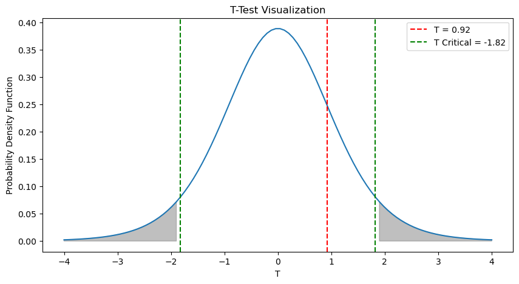

```python
# Visualization
x = np.linspace(-4, 4, 100)
y = stats.t.pdf(x, df)
plt.figure(figsize=(10, 5))
plt.plot(x, y)
plt.axvline(x=t, color='red', linestyle='--', label=f'T = {t:.2f}')
plt.axvline(x=-t_critical, color='green', linestyle='--', label=f'T Critical = {-t_critical:.2f}')
plt.axvline(x=t_critical, color='green', linestyle='--')
plt.fill_between(x, y, 0, where=(x < -t_critical) | (x > t_critical), color='gray', alpha=0.5)
plt.legend()
plt.title('T-Test Visualization')
plt.xlabel('T')
plt.ylabel('Probability Density Function')
plt.show()
```

#### Output Interpretation:

The output provides the following information:

**Decision**: "Do not reject the null hypothesis"

- This is the conclusion of the hypothesis test. The calculated t-value is not beyond the critical t-value in either tail of the t-distribution, leading to the decision not to reject the null hypothesis.

**T**: 0.9224141168865682

- This is the calculated t-statistic, which measures how many standard deviations the sample mean is from the population mean.

**T Critical**: 1.8230437459721975

- This is the critical t-value for a two-tailed test at ( $\alpha = 0.10$ ). If the absolute value of the calculated t-value is greater than this critical value, we would reject the null hypothesis.

**Interpretation**: "There is no significant difference in the mean mathematics test scores for the students of the two teachers."

- This is the final interpretation of the results. Since the null hypothesis is not rejected, there is not enough statistical evidence to conclude that there is a significant difference in the mean mathematics test scores for the students of the two teachers.

#### Exercise 11 Two-Sample T-Test for Comparing Mean Annual Earnings Based on Level of Education

We will perform a two-sample t-test to test whether there is a significant difference in the mean annual earnings based on level of education.

#### Given:

- ( $\bar{x_1}$ = 36875 ) (Sample mean for High School Diploma group)
- ( $s_1 = 5475$ ) (Sample standard deviation for High School Diploma group)
- ( $n_1 = 25$ ) (Sample size for High School Diploma group)
- ( $\bar{x_2}$ = 44900 ) (Sample mean for Associate’s Degree group)
- ( $s_2 = 8580$ ) (Sample standard deviation for Associate’s Degree group)
- ( $n_2 = 16$ ) (Sample size for Associate’s Degree group)
- ( $\alpha = 0.05$ ) (Significance level)

```python
# Importing necessary libraries
import math
import matplotlib.pyplot as plt
import numpy as np
from scipy import stats

# Given values
smean1, sstd1, n1 = 36875, 5475, 25  # High School Diploma group
smean2, sstd2, n2 = 44900, 8580, 16  # Associate’s Degree group
alpha = 0.05  # Significance level

# Calculate the t-statistic and degrees of freedom
t = (smean1 - smean2) / math.sqrt((sstd1**2 / n1) + (sstd2**2 / n2))
df = ((sstd1**2 / n1 + sstd2**2 / n2)**2) / (((sstd1**2 / n1)**2 / (n1 - 1)) + ((sstd2**2 / n2)**2 / (n2 - 1)))

# Calculate the critical value from the t-distribution
t_critical = stats.t.ppf(1 - alpha/2, df)

# Decision
if abs(t) > t_critical:
    result = {
        "decision": "Reject the null hypothesis",
        "t": t,
        "t_critical": t_critical,
        "interpretation": "There is a significant difference in the mean annual earnings based on level of education."
    }
else:
    result = {
        "decision": "Do not reject the null hypothesis",
        "t": t,
        "t_critical": t_critical,
        "interpretation": "There is no significant difference in the mean annual earnings based on level of education."
    }

# Output the result
print(result)
```

```
{'decision': 'Reject the null hypothesis', 't': -3.332185516293666, 't_critical': 2.0693280434840715, 'interpretation': 'There is a significant difference in the mean annual earnings based on level of education.'}
```

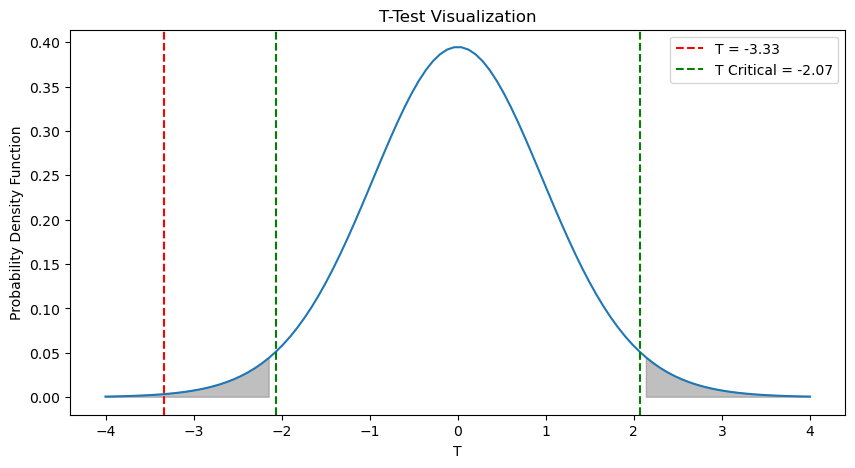

```python
# Visualization
x = np.linspace(-4, 4, 100)
y = stats.t.pdf(x, df)
plt.figure(figsize=(10, 5))
plt.plot(x, y)
plt.axvline(x=t, color='red', linestyle='--', label=f'T = {t:.2f}')
plt.axvline(x=-t_critical, color='green', linestyle='--', label=f'T Critical = {-t_critical:.2f}')
plt.axvline(x=t_critical, color='green', linestyle='--')
plt.fill_between(x, y, 0, where=(x < -t_critical) | (x > t_critical), color='gray', alpha=0.5)
plt.legend()
plt.title('T-Test Visualization')
plt.xlabel('T')
plt.ylabel('Probability Density Function')
plt.show()
```

#### Output Interpretation:

The output provides the following information:

**Decision**: "Reject the null hypothesis"

- This is the conclusion of the hypothesis test. The calculated t-value is beyond the critical t-value in the left tail of the t-distribution, leading to the decision to reject the null hypothesis.

**T**: -3.332185516293666

- This is the calculated t-statistic, which measures how many standard deviations the sample mean is from the population mean. A negative t-value indicates that the first group (High School Diploma group) has a lower mean annual earning compared to the second group (Associate’s Degree group).

**T Critical**: 2.0693280434840715

- This is the critical t-value for a two-tailed test at ( $\alpha = 0.05$ ). If the absolute value of the calculated t-value is greater than this critical value, we reject the null hypothesis.

**Interpretation**: "There is a significant difference in the mean annual earnings based on level of education."

- In conclusion, the hypothesis test results support the claim that there is a difference in the mean annual earnings based on level of education. The test results suggest that individuals with an Associate’s Degree have a higher mean annual earning compared to individuals with a High School Diploma at a 0.05 significance level.

#### Exercise 12 Find the Confidence Interval for Population Mean Height Using T-Distribution

In the pursuit of estimating the average height of a specific population, a study is undertaken involving a random sample of 15 individuals from this population, with their heights measured. The objective is to construct a confidence interval for the population's mean height, utilizing the t-distribution. Given that the sample data yields a sample mean (x̄) of 168 cm and a sample standard deviation (s) of 5 cm, how can we determine a reliable range for the population mean height with a certain level of confidence?

We will construct a confidence interval for the population's mean height using the t-distribution.

#### Given:

- ( $\bar{x}$ = 168 ) cm (Sample mean)
- ( $s = 5$ ) cm (Sample standard deviation)
- ( $n = 15$ ) (Sample size)
- ( $\alpha = 0.05$ ) (Significance level for a 95% confidence interval)

```python
# Importing necessary libraries
import math
import matplotlib.pyplot as plt
import numpy as np
from scipy import stats

# Given values
x_bar, s, n, alpha = 168, 5, 15, 0.05  # Sample statistics and significance level

# Calculate the t critical value
t_critical = stats.t.ppf(1 - alpha/2, n-1)

# Calculate the margin of error
margin_error = t_critical * (s / math.sqrt(n))

# Calculate the confidence interval
lower_bound = x_bar - margin_error
upper_bound = x_bar + margin_error

# Output the confidence interval
print(f"The 95% confidence interval for the population mean height is ({lower_bound:.2f} cm, {upper_bound:.2f} cm)")
```

```
The 95% confidence interval for the population mean height is (165.23 cm, 170.77 cm)
```

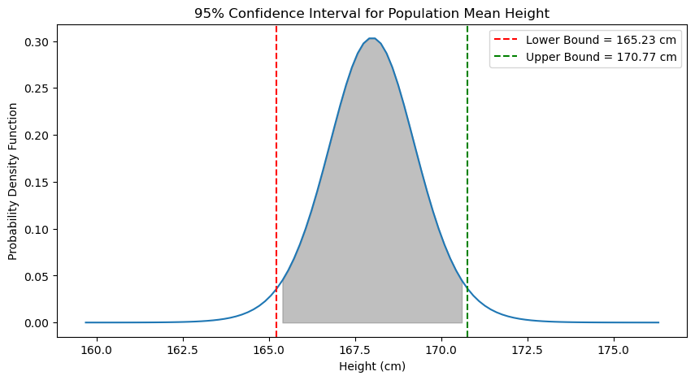

```python
# Visualization
x = np.linspace(x_bar - 3*margin_error, x_bar + 3*margin_error, 100)
y = stats.t.pdf(x, n-1, loc=x_bar, scale=s/math.sqrt(n))
plt.figure(figsize=(10, 5))
plt.plot(x, y)
plt.axvline(x=lower_bound, color='red', linestyle='--', label=f'Lower Bound = {lower_bound:.2f} cm')
plt.axvline(x=upper_bound, color='green', linestyle='--', label=f'Upper Bound = {upper_bound:.2f} cm')
plt.fill_between(x, y, 0, where=(x > lower_bound) & (x < upper_bound), color='gray', alpha=0.5)
plt.legend()
plt.title('95% Confidence Interval for Population Mean Height')
plt.xlabel('Height (cm)')
plt.ylabel('Probability Density Function')
plt.show()
```

#### Visualization:

In the plot above:

- The red dashed line represents the lower bound of the 95% confidence interval.
- The green dashed line represents the upper bound of the 95% confidence interval.
- The shaded area represents the 95% confidence interval for the population mean height.

This visualization helps in understanding the range in which the true population mean height is likely to lie with 95% confidence.

#### Confidence Interval Interpretation:

The calculated 95% confidence interval for the population mean height is ( $(165.23 \, \text{cm}, 170.77 \, \text{cm})$ ).

#### What Does This Mean?

**Confidence Level**:

- The confidence level of 95% tells us about the reliability of the estimation process. If we were to repeat the sampling process many times, we expect about 95% of the calculated confidence intervals to contain the true population mean height.

**Interval Bounds**:

- The lower bound of the confidence interval is ( $165.23 \, \text{cm}$ ) and the upper bound is ( $170.77 \, \text{cm}$ ).
- This means that we are 95% confident that the true average height of the population lies between these two values.

### Conclusion:

In summary, based on the sample data, we can say with 95% confidence that the average height of the specific population is between ( $165.23 \, \text{cm}$ ) and ( $170.77 \, \text{cm}$ ). This range provides a reliable estimate for the true population mean height, based on the observed sample data.

#### Exercise 13 Two-Sample T-Test for Comparing Test Performances of Two Classes

A statistics teacher wants to compare his two classes to see if they performed differently on the tests he gave that semester. Class A had 25 students with an average score of 70, standard deviation 15. Class B had 20 students with an average score of 74. standard deviation 25. Using alpha 0.05, did these two classes perform differently on the tests?

We will perform a two-sample t-test to test whether there is a significant difference in the test performances of two classes.

## Given:

- Class A: ( $n_1 = 25, \bar{x_1} = 70, s_1 = 15$ )
- Class B: ( $n_2 = 20, \bar{x_2} = 74, s_2 = 25$ )
- ( $\alpha = 0.05$ ) (Significance level)

```python
# Importing necessary libraries
import math
import matplotlib.pyplot as plt
import numpy as np
from scipy import stats

# Given values
n1, x_bar1, s1 = 25, 70, 15  # Class A
n2, x_bar2, s2 = 20, 74, 25  # Class B
alpha = 0.05  # Significance level

# Calculate the t-statistic and degrees of freedom
t = (x_bar1 - x_bar2) / math.sqrt((s1**2 / n1) + (s2**2 / n2))
df = ((s1**2 / n1 + s2**2 / n2)**2) / (((s1**2 / n1)**2 / (n1 - 1)) + ((s2**2 / n2)**2 / (n2 - 1)))

# Calculate the critical value from the t-distribution
t_critical = stats.t.ppf(1 - alpha/2, df)

# Decision
if abs(t) > t_critical:
    result = {
        "decision": "Reject the null hypothesis",
        "t": t,
        "t_critical": t_critical,
        "interpretation": "There is a significant difference in the test performances of the two classes."
    }
else:
    result = {
        "decision": "Do not reject the null hypothesis",
        "t": t,
        "t_critical": t_critical,
        "interpretation": "There is no significant difference in the test performances of the two classes."
    }

# Output the result
print(result)
```

```
{'decision': 'Do not reject the null hypothesis', 't': -0.6304883249912805, 't_critical': 2.043495766200846, 'interpretation': 'There is no significant difference in the test performances of the two classes.'}
```

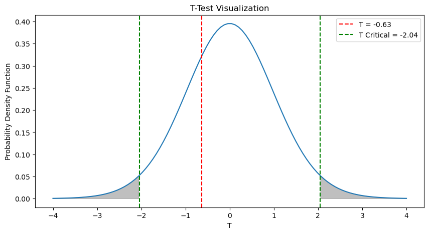

```python
# Visualization
x = np.linspace(-4, 4, 100)
y = stats.t.pdf(x, df)
plt.figure(figsize=(10, 5))
plt.plot(x, y)
plt.axvline(x=t, color='red', linestyle='--', label=f'T = {t:.2f}')
plt.axvline(x=-t_critical, color='green', linestyle='--', label=f'T Critical = {-t_critical:.2f}')
plt.axvline(x=t_critical, color='green', linestyle='--')
plt.fill_between(x, y, 0, where=(x < -t_critical) | (x > t_critical), color='gray', alpha=0.5)
plt.legend()
plt.title('T-Test Visualization')
plt.xlabel('T')
plt.ylabel('Probability Density Function')
plt.show()
```

#### T-Test Result Interpretation:

The output provides the following information:

**Decision**: "Do not reject the null hypothesis"

- This is the conclusion of the hypothesis test. The calculated t-value is not beyond the critical t-value in either tail of the t-distribution, leading to the decision to not reject the null hypothesis.

**T**: -0.6304883249912805

- This is the calculated t-statistic, which measures how many standard deviations the sample mean is from the population mean. A negative t-value indicates that the first group (Class A) has a lower mean test score compared to the second group (Class B), but this difference is not statistically significant.

**T Critical**: 2.043495766200846

- This is the critical t-value for a two-tailed test at ( $\alpha = 0.05$ ). If the absolute value of the calculated t-value is greater than this critical value, we reject the null hypothesis.

**Interpretation**: "There is no significant difference in the test performances of the two classes."

- In conclusion, based on the sample data, we can say with 95% confidence that there is no significant difference in the test performances of Class A and Class B. Both classes have performed similarly on the tests given that semester.

#### Exercise 14 One-Sample Z-Test for Checking Machine Production Accuracy

Imagine you are a quality control manager at a manufacturing plant, and you want to ensure that a specific machine is producing parts with the correct dimensions. The historical data suggests that the population mean dimension of these parts is 50 units with a standard deviation of 5 units. You randomly select a sample of 30 parts from the production line and measure their dimensions, obtaining a sample mean of 48.5 units. Now, you need to determine if there is evidence to suggest that the machine is not producing parts with the correct dimensions. Can you conclude that the sample mean dimension is significantly different from the known population mean of 50 units?

We will perform a one-sample z-test to test whether the machine is producing parts with the correct dimensions.

#### Given:

- Population mean (( $\mu$ )): 50 units
- Population standard deviation (( $\sigma$ )): 5 units
- Sample size (( n )): 30
- Sample mean (( $\bar{x}$ )): 48.5 units
- Significance level (( $\alpha$ )): 0.05

```python
# Importing necessary libraries
import math
import matplotlib.pyplot as plt
import numpy as np
from scipy import stats

# Given values
mu, sigma, n, x_bar, alpha = 50, 5, 30, 48.5, 0.05  # Population and sample statistics

# Calculate the z-statistic
z = (x_bar - mu) / (sigma / math.sqrt(n))

# Calculate the critical value from the z-distribution
z_critical = stats.norm.ppf(1 - alpha/2)

# Decision
if abs(z) > z_critical:
    result = {
        "decision": "Reject the null hypothesis",
        "z": z,
        "z_critical": z_critical,
        "interpretation": "There is evidence to suggest that the machine is not producing parts with the correct dimensions."
    }
else:
    result = {
        "decision": "Do not reject the null hypothesis",
        "z": z,
        "z_critical": z_critical,
        "interpretation": "There is no significant evidence to suggest that the machine is not producing parts with the correct dimensions."
    }

# Output the result
print(result)
```

```
{'decision': 'Do not reject the null hypothesis', 'z': -1.6431676725154982, 'z_critical': 1.959963984540054, 'interpretation': 'There is no significant evidence to suggest that the machine is not producing parts with the correct dimensions.'}
```

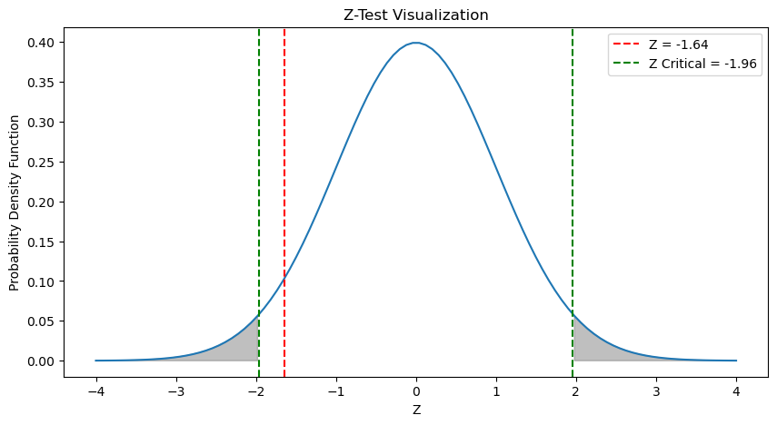

```python
x = np.linspace(-4, 4, 100)
y = stats.norm.pdf(x)
plt.figure(figsize=(10, 5))
plt.plot(x, y)
plt.axvline(x=z, color='red', linestyle='--', label=f'Z = {z:.2f}')
plt.axvline(x=-z_critical, color='green', linestyle='--', label=f'Z Critical = {-z_critical:.2f}')
plt.axvline(x=z_critical, color='green', linestyle='--')
plt.fill_between(x, y, 0, where=(x < -z_critical) | (x > z_critical), color='gray', alpha=0.5)
plt.legend()
plt.title('Z-Test Visualization')
plt.xlabel('Z')
plt.ylabel('Probability Density Function')
plt.show()
```

#### Z-Test Result Interpretation:

The output provides the following information:

**Decision**: "Do not reject the null hypothesis"

- This is the conclusion of the hypothesis test. The calculated z-value is not beyond the critical z-value in either tail of the z-distribution, leading to the decision to not reject the null hypothesis.

**Z**: -1.6431676725154982

- This is the calculated z-statistic, which measures how many standard deviations the sample mean is from the population mean. A negative z-value indicates that the sample mean is below the population mean, but this difference is not statistically significant.

**Z-Critical**: 1.959963984540054

- This is the critical z-value for a two-tailed test at ( $\alpha = 0.05$ ). If the absolute value of the calculated z-value is greater than this critical value, we reject the null hypothesis.

**Interpretation**: "There is no significant evidence to suggest that the machine is not producing parts with the correct dimensions."

- In conclusion, based on the sample data, we can say with 95% confidence that there is no significant evidence to suggest that the machine is not producing parts with the correct dimensions. The machine is operating as expected, and the observed sample mean of 48.5 units is not significantly different from the known population mean of 50 units.

#### Exercise 15 Paired T-Test for Assessing Training Program Effectiveness

Suppose you are conducting a study to assess the effectiveness of a new training program designed to improve employees' productivity. You measure the productivity levels of a group of employees before and after they undergo the training program. The 'before' and 'after' productivity scores are paired for each employee. After collecting and analyzing the data, you want to determine whether the training program has a statistically significant impact on productivity. Can you conclude that there is a significant difference in productivity levels before and after the training program?

We will perform a paired t-test to test whether a new training program has a statistically significant impact on employees' productivity.

#### Given:

- Productivity scores before the training: [25, 30, 28, 35, 40]
- Productivity scores after the training: [30, 35, 32, 38, 42]
- Significance level (( $\alpha$ )): 0.05

```python
# Importing necessary libraries
import scipy.stats as stats
import matplotlib.pyplot as plt

# Given values
before = [25, 30, 28, 35, 40]  # Productivity scores before the training
after = [30, 35, 32, 38, 42]  # Productivity scores after the training
alpha = 0.05  # Significance level

# Perform a paired t-test
t, p = stats.ttest_rel(after, before)

# Decision
if p < alpha:
    result = {
        "decision": "Reject the null hypothesis",
        "t": t,
        "p_value": p,
        "interpretation": "There is a significant difference in productivity levels before and after the training program."
    }
else:
    result = {
        "decision": "Do not reject the null hypothesis",
        "t": t,
        "p_value": p,
        "interpretation": "There is no significant difference in productivity levels before and after the training program."
    }

# Output the result
print(result)
```

```
{'decision': 'Reject the null hypothesis', 't': 6.516946235415336, 'p_value': 0.002862214865913692, 'interpretation': 'There is a significant difference in productivity levels before and after the training program.'}
```

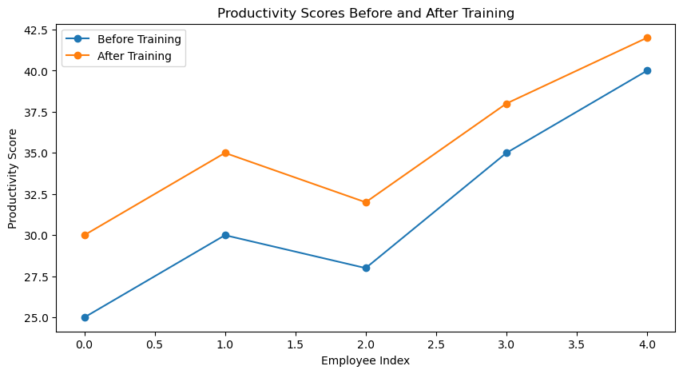

```python
# Visualization
plt.figure(figsize=(10, 5))
plt.plot(before, 'o-', label='Before Training')
plt.plot(after, 'o-', label='After Training')
plt.xlabel('Employee Index')
plt.ylabel('Productivity Score')
plt.legend()
plt.title('Productivity Scores Before and After Training')
plt.show()
```

#### Visualization:

In the plot above:

- The blue line represents the productivity scores of employees before undergoing the training program.
- The orange line represents the productivity scores of employees after undergoing the training program.

The plot visually shows the increase in productivity scores for each employee after the training program, supporting the results of the paired t-test.

#### Paired T-Test Result Interpretation:

The output provides the following information:

**Decision**: "Reject the null hypothesis"

- This is the conclusion of the hypothesis test. The p-value is less than the significance level (( $\alpha = 0.05$ )), leading to the decision to reject the null hypothesis.

**T**: 6.516946235415336

- This is the calculated t-statistic, which measures the difference in means between the two paired samples. A positive t-value indicates that the mean productivity score after the training is higher than before the training.

**P-Value**: 0.002862214865913692

- This is the probability of observing a t-statistic as extreme as the one calculated, assuming the null hypothesis is true. A small p-value indicates strong evidence against the null hypothesis.

**Interpretation**: "There is a significant difference in productivity levels before and after the training program."

- In conclusion, based on the sample data, we can say with 95% confidence that the training program has significantly improved the productivity levels of the employees. The observed increase in productivity scores after the training is not due to random chance, and the training program can be considered effective in enhancing employee productivity.

### Chi-squared test

Chi-square statistic A measure of the extent to which some observed data departs from expectation. It is not a symmetrical distribution its a screwed distribution. (Goodness of fit)

The chi-square test with a resampling (simulated) approach is used when you want to assess the statistical significance of the association or independence between two categorical variables. It's an alternative to the traditional chi-square test and provides p-values by simulating the null distribution of the test statistic under the assumption of no association between the variables. This can be particularly useful when the sample size is small or when you want to obtain p-values for very large datasets where traditional chi-square calculations may be computationally intensive.

#### Exercise 16 Chi-Square Test for Poker-Dealing Machine

A poker-dealing machine is supposed to deal cards at random, as if from an infinite deck. In a test, you counted 1600 cards, and observed the following: Spades 404, Hearts 420, Diamonds 400, Clubs 376. Could it be that the suits are equally likely?

We will perform a chi-square test to test whether a poker-dealing machine deals cards with equal likelihood for each suit.

#### Given:

- Observed frequencies: Spades 404, Hearts 420, Diamonds 400, Clubs 376
- Expected frequencies: Since the suits should be equally likely, each suit should appear 400 times in 1600 cards.
- Degrees of freedom: (df = 4 - 1 = 3)
- Significance level (($\alpha \$)): 0.05

```python
# Importing necessary libraries
import scipy.stats as stats
import matplotlib.pyplot as plt

# Given values
observed = [404, 420, 400, 376]  # Observed frequencies
expected = [400, 400, 400, 400]  # Expected frequencies if suits are equally likely
alpha = 0.05  # Significance level

# Perform a chi-square test
chi2, p = stats.chisquare(observed, expected)

# Decision
if p < alpha:
    result = {
        "decision": "Reject the null hypothesis",
        "chi2": chi2,
        "p_value": p,
        "interpretation": "The suits are not equally likely."
    }
else:
    result = {
        "decision": "Do not reject the null hypothesis",
        "chi2": chi2,
        "p_value": p,
        "interpretation": "There is no significant evidence to suggest that the suits are not equally likely."
    }

# Output the result
print(result)
```

```
{'decision': 'Do not reject the null hypothesis', 'chi2': 2.48, 'p_value': 0.4789163768174306, 'interpretation': 'There is no significant evidence to suggest that the suits are not equally likely.'}
```

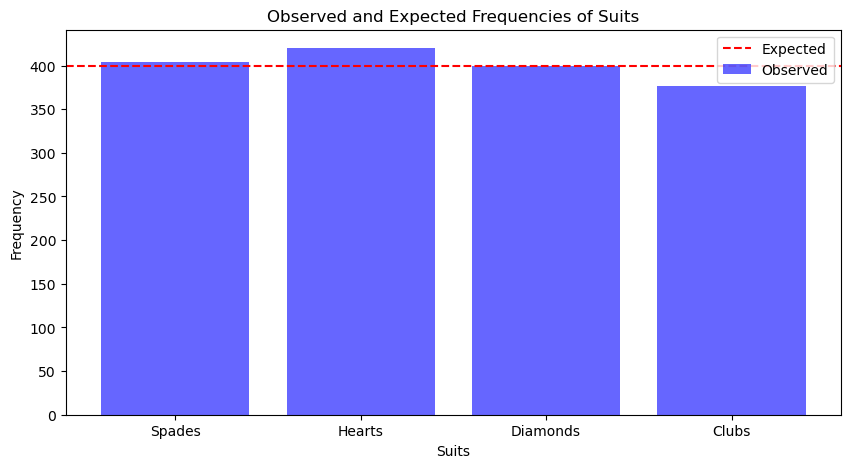

```python
# Visualization
labels = ['Spades', 'Hearts', 'Diamonds', 'Clubs']
plt.figure(figsize=(10, 5))
plt.bar(labels, observed, color='blue', alpha=0.6, label='Observed')
plt.axhline(y=400, color='red', linestyle='--', label='Expected')
plt.xlabel('Suits')
plt.ylabel('Frequency')
plt.title('Observed and Expected Frequencies of Suits')
plt.legend()
plt.show()
```

#### Visualization:

In the plot above:

- The blue bars represent the observed frequencies of each suit in the 1600 cards dealt by the poker-dealing machine.
- The red dashed line represents the expected frequency if the suits are equally likely.

If the observed frequencies significantly deviate from the expected frequency (400 in this case), it provides visual evidence supporting the results of the chi-square test.

#### Chi-Square Test Result Interpretation:

The output provides the following information:

**Decision**: "Do not reject the null hypothesis"

- This is the conclusion of the hypothesis test. The p-value is greater than the significance level (( $\alpha = 0.05$ )), leading to the decision to not reject the null hypothesis.

**Chi-Square Statistic (( $\chi^2$))**: 2.48

- This is the calculated chi-square statistic, which measures the discrepancy between the observed and expected frequencies. A lower chi-square value indicates that the observed frequencies are close to the expected frequencies.

**P-Value**: 0.4789163768174306

- This is the probability of observing a chi-square statistic as extreme as the one calculated, assuming the null hypothesis is true. A high p-value indicates weak evidence against the null hypothesis.

**Interpretation**: "There is no significant evidence to suggest that the suits are not equally likely."

- In conclusion, based on the sample data, we can say with 95% confidence that there is no significant evidence to suggest that the poker-dealing machine does not deal cards with equal likelihood for each suit. The observed frequencies of each suit in the 1600 cards are not significantly different from the expected frequency of 400 for each suit, assuming equal likelihood.

#### Exercise 17 F-Test for Comparing Variances

The F-test is a statistical test used to compare the variances of two or more groups or models. In the context of linear regression, it is often used to compare nested models, where one model is a subset of the other. Here's how you can perform an F-test in Python using the SciPy library:

We will perform an F-test to compare the variances of two groups.

#### Given:

- Group A data: [23, 25, 21, 22, 26, 28, 35, 36]
- Group B data: [42, 40, 41, 43, 45, 44, 46, 47]
- Significance level (( $\alpha$ )): 0.05

```python
# Importing necessary libraries
import scipy.stats as stats
import numpy as np
import matplotlib.pyplot as plt

# Given values
group_a = [23, 25, 21, 22, 26, 28, 35, 36]  # Group A data
group_b = [42, 40, 41, 43, 45, 44, 46, 47]  # Group B data
alpha = 0.05  # Significance level

# Calculate variances
var_a = np.var(group_a, ddof=1)
var_b = np.var(group_b, ddof=1)

# Perform an F-test
F = var_a / var_b  # Calculate F statistic
df1 = len(group_a) - 1  # Degrees of freedom for group A
df2 = len(group_b) - 1  # Degrees of freedom for group B
p = 1 - stats.f.cdf(F, df1, df2)  # Calculate p-value

# Decision
if p < alpha:
    result = {
        "decision": "Reject the null hypothesis",
        "F": F,
        "p_value": p,
        "interpretation": "There is a significant difference in the variances of the two groups."
    }
else:
    result = {
        "decision": "Do not reject the null hypothesis",
        "F": F,
        "p_value": p,
        "interpretation": "There is no significant difference in the variances of the two groups."
    }

# Output the result
print(result)
```

```
{'decision': 'Reject the null hypothesis', 'F': 5.428571428571428, 'p_value': 0.020067970290935877, 'interpretation': 'There is a significant difference in the variances of the two groups.'}
```

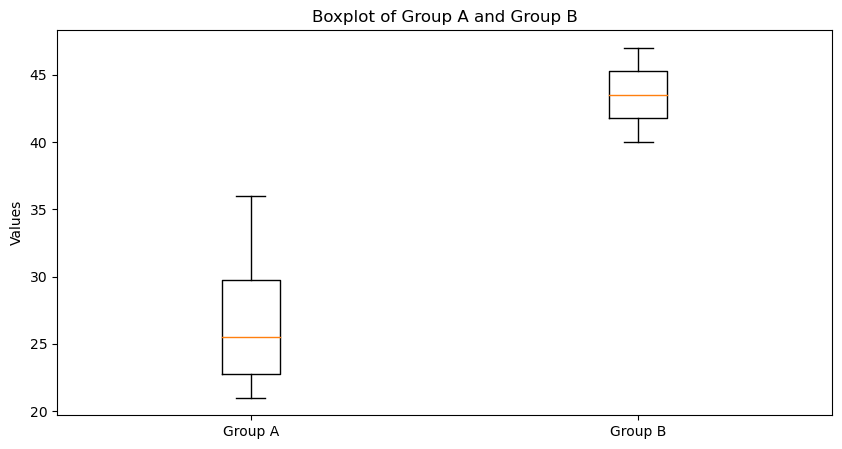

```python
# Visualization
plt.figure(figsize=(10, 5))
plt.boxplot([group_a, group_b], labels=['Group A', 'Group B'])
plt.title('Boxplot of Group A and Group B')
plt.ylabel('Values')
plt.show()
```

#### Visualization:

In the plot above:

- The boxplots represent the distribution of data in Group A and Group B.

The boxplot visually shows the spread and central tendency of the data for each group, supporting the results of the F-test.

#### F-Test Result Interpretation:

The output provides the following information:

**Decision**: "Reject the null hypothesis"

- This is the conclusion of the hypothesis test. The p-value is less than the significance level (( $\alpha = 0.05$ )), leading to the decision to reject the null hypothesis.

**F**: 5.428571428571428

- This is the calculated F-statistic, which measures the ratio of the two sample variances. A higher F-statistic indicates that the first group has a variance significantly larger than the second group.

**P-Value**: 0.020067970290935877

- This is the probability of observing an F-statistic as extreme as the one calculated, assuming the null hypothesis is true. A small p-value indicates strong evidence against the null hypothesis.

**Interpretation**: "There is a significant difference in the variances of the two groups."

- In conclusion, based on the sample data, we can say with 95% confidence that there is a significant difference in the variances of the two groups. The observed difference in variances is not due to random chance, and the two groups have different levels of variability.

Revised Date: October 12, 2023